# Structural Topic Model - Government-Business Relationship in Academic Literature

Václav Ocelík

2020-09-08

**The** following is a structural topic model analysis of abstract from academic articles on the relationship between politics and business published between 1990 and 2020. The articles were acquired through *Thomson Reuters Web of Knowledge*. The following keywords search was used:

_TS = (“corporate politic*" OR "business politic*” OR “nonmarket” OR "political manag*" OR “regulatory capture” OR “corporate public”)_.

```r
rm(list=ls())

library(furrr)
library(GGally)
library(ggthemes)
library(gridExtra)
library(knitr)
library(kableExtra)
library(lubridate)
library(readxl)
library(tidylo)
library(tidystm)
library(tidytext)
library(tidyverse)
library(scales)
library(stm)
library(tm)

theme_set(theme_classic())
```

Some of the columns are not parsed consistently throughout all dataframes. This creates issues when attempting to bind the datasets together. Given the fact that these specific columns are not relevant to the analysis, I simply drop them from all datasets that I import.

```r
# Import data ####
df <- do.call(rbind, lapply(Sys.glob("data/new_data/*.xls"), read_excel)) # make sure no other .xls files in target.
```

A list of all variables.

```r
relevant_cols <- df %>%
  janitor::clean_names() %>%
  select(authors, article_title, source_title, abstract,
           publication_year, times_cited_all_databases,
           author_keywords, keywords_plus, publication_date) %>%
  names()

relevant_row_nums <- df %>%
  janitor::clean_names() %>%
  names() %>%
  as_tibble_col(column_name = "Variable") %>%
  filter(Variable != "x68") %>%
  mutate(row_num = row_number()) %>%
  filter(Variable %in% relevant_cols) %>%
  pull(row_num)

df %>%
  janitor::clean_names() %>%
  names() %>%
  as_tibble_col(column_name = "Variable") %>%
  filter(Variable != "x68") %>%
  kbl(caption = "All variables from the data set provided by WOS.") %>%
  kable_classic("striped", full_width = F) %>%
  row_spec(relevant_row_nums, bold = T) %>%
  footnote(general = "Bold names are used in the structural topic model.")
```

All variables from the data set provided by WOS.

| Variable |
| --- |
| publication_type |
| authors |
| book_authors |
| book_editors |
| book_group_authors |
| author_full_names |
| book_author_full_names |
| group_authors |
| article_title |
| source_title |
| book_series_title |
| book_series_subtitle |
| language |
| document_type |
| conference_title |
| conference_date |
| conference_location |
| conference_sponsor |
| conference_host |
| author_keywords |
| keywords_plus |
| abstract |
| addresses |
| reprint_addresses |
| email_addresses |
| researcher_ids |
| orci_ds |
| funding_orgs |
| funding_text |
| cited_references |
| cited_reference_count |
| times_cited_wo_s_core |
| times_cited_all_databases |
| x180_day_usage_count |
| since_2013_usage_count |
| publisher |
| publisher_city |
| publisher_address |
| issn |
| e_issn |
| isbn |
| journal_abbreviation |
| journal_iso_abbreviation |
| publication_date |
| publication_year |
| volume |
| issue |
| part_number |
| supplement |
| special_issue |
| meeting_abstract |
| start_page |
| end_page |
| article_number |
| doi |
| book_doi |
| early_access_date |
| number_of_pages |
| wo_s_categories |
| research_areas |
| ids_number |
| ut_unique_wos_id |
| pubmed_id |
| open_access_designations |
| highly_cited_status |
| hot_paper_status |
| date_of_export |

Note:  
Bold names are used in the structural topic model.

```r
rm(relevant_cols, relevant_row_nums)
```

A small (N = 5) random sample from the data.

```r
# keep only the necessary columns
df_clean <- df %>%
  janitor::clean_names() %>%
  select(authors, `article_title`, `source_title`, abstract,
         `publication_year`, `times_cited_all_databases`,
         `author_keywords`, `keywords_plus`, publication_date)
```

```r
df_clean %>%
  select(authors, `article_title`, `publication_year`, `times_cited_all_databases`,
         abstract) %>%
  drop_na() %>%
  sample_n(5) %>%
  kbl(caption = "A snapshot of the data") %>%
  kable_classic("striped", full_width = FALSE) %>%
  footnote(general = "Rows were randomly selected.")
```

A snapshot of the data

| authors | article_title | publication_year | times_cited_all_databases | abstract |
| --- | --- | --- | --- | --- |
| Guthman, J | Regulating meaning, appropriating nature: The codification of California organic agriculture | 1998 | 138 | In California, conventional agro-food firms are beginning to appropriate the most lucrative aspects of organic food provision and to abandon the agronomic and marketing practices associated with organ… |
| GREENHALGH, S | DE-ORIENTALIZING THE CHINESE FAMILY FIRM | 1994 | 81 | Since the 1960s, East Asia’s ‘’four little dragons’’ have become the fastest growing areas of the world economy. Inspired by a newfound pride in the traditions of Chinese culture, Chinese scholars and… |
| Bonaime, A; Gulen, H; Ion, M | Does policy uncertainty affect mergers and acquisitions? | 2018 | 56 | Political and regulatory uncertainty is strongly negatively associated with merger and acquisition activity at the macro and firm levels. The strongest effects are for uncertainty regarding taxes, gov… |
| Valliere, D; Peterson, R | Entrepreneurship and economic growth: Evidence from emerging and developed countries | 2009 | 140 | This paper presents an extension to the economic growth model developed by Wong, Ho, and Autio (2005), to reflect differences in the economic effects of opportunity and necessity-based entrepreneurshi… |
| Sud, M; VanSandt, CV; Baugous, AM | Social Entrepreneurship: The Role of Institutions | 2009 | 99 | A relatively small segment of business, known as social entrepreneurship (SE), is increasingly being acknowledged as an effective source of solutions for a variety of social problems. Because society … |

Note:  
Rows were randomly selected.

Exploring the citation variable.

```r
df_clean %>%
  filter(`times_cited_all_databases` < 2000,
         !is.na(`publication_year`)) %>%
  ggplot(aes(x = `publication_year`, y = `times_cited_all_databases`)) +
  geom_point(aes(color = `times_cited_all_databases` > 250), show.legend = F)

df_clean %>%
  filter(`times_cited_all_databases` < 250,
         !is.na(`publication_year`)) %>%
  ggplot(aes(x = `publication_year`, y = `times_cited_all_databases`)) +
  geom_point(aes(color = `times_cited_all_databases` > 100), show.legend = F)

df_clean %>%
  filter(`times_cited_all_databases` < 100,
         !is.na(`publication_year`)) %>%
  ggplot(aes(x = `publication_year`, y = `times_cited_all_databases`)) +
  geom_point(aes(color = `times_cited_all_databases` > 25), show.legend = F)
```

[output not shown]

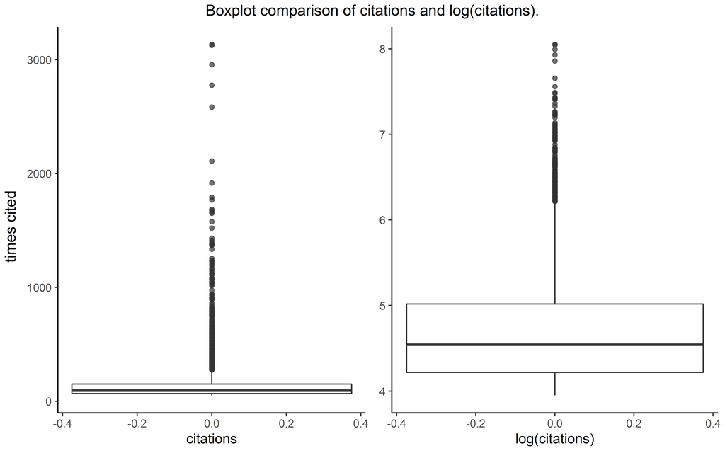

```r
cite_boxplot <- df_clean %>%
  ggplot(aes(times_cited_all_databases)) +
  geom_boxplot(outlier.alpha = .7) +
  coord_flip() +
  labs(x = NULL,
       y = "citations")

cite_boxplot_log <- df_clean %>%
  ggplot(aes(log(times_cited_all_databases))) +
  geom_boxplot(outlier.alpha = .7) +
  coord_flip() +
  labs(x = NULL,
       y = "log(citations)")

cite_hist <- df_clean %>%
  ggplot(aes(times_cited_all_databases)) +
  geom_histogram(color = "white") +
  labs(y = NULL,
       x = "citations")

cite_hist_log <- df_clean %>%
  ggplot(aes(log(times_cited_all_databases))) +
  geom_histogram(color = "white") +
  labs(y = NULL,
       x = "log(citations)")

grid.arrange(cite_boxplot, cite_boxplot_log,
             ncol = 2,
             top = "Boxplot comparison of citations and log(citations).",
             left = "times cited")
```

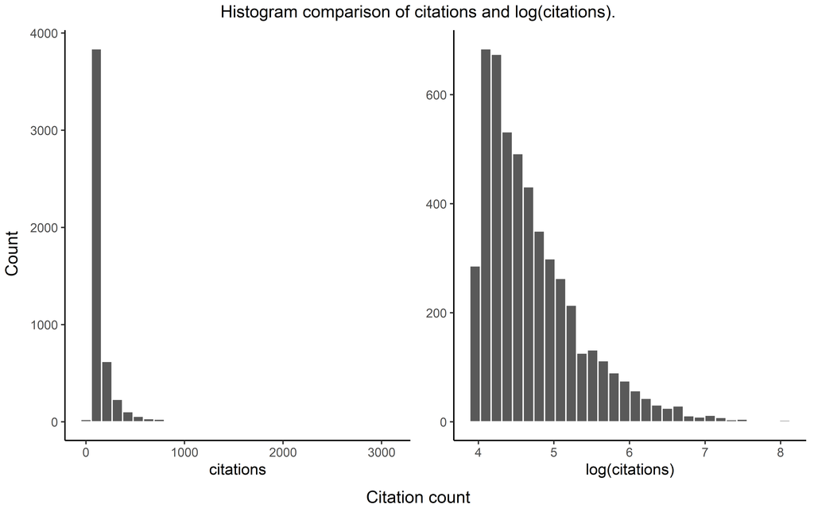

```r
grid.arrange(cite_hist, cite_hist_log,
             ncol = 2,
             top = "Histogram comparison of citations and log(citations).",
             left = "Count",
             bottom = "Citation count")
```

```r
rm(cite_boxplot, cite_boxplot_log, cite_hist, cite_hist_log)
```

As we can see, taking the natural logarithm mitigates the skewness somewhat, but long right-tails remain.

```r
# creating some additional variables
df_clean <- df_clean %>%
  filter(!is.na(`publication_year`),
         !is.na(abstract),
         !is.na(publication_date)) %>%
  mutate(ID = row_number(),
         abstract_Length = str_length(abstract),
         publication_date = case_when(publication_date == "JAN" ~ 1,
                                      publication_date == "FEB" ~ 2,
                                      publication_date == "MAR" ~ 3,
                                      publication_date == "APR" ~ 4,
                                      publication_date == "MAY" ~ 5,
                                      publication_date == "JUN" ~ 6,
                                      publication_date == "JUL" ~ 7,
                                      publication_date == "AUG" ~ 8,
                                      publication_date == "SEP" ~ 9,
                                      publication_date == "OCT" ~ 10,
                                      publication_date == "NOV" ~ 11,
                                      publication_date == "DEC" ~ 12)) %>%
  filter(!is.na(publication_date)) %>%
  unite("date", publication_year, publication_date, sep = "-") %>%
  mutate(date = paste(date, "01", sep = "-"), date = as.Date(date),
         months_since_first_pub = interval(min(date), date),
         months_since_first_pub = months_since_first_pub %/% months(1) + 1)
```

Next, I import the journal data from the [Web of Science Master Journal List](https://mjl.clarivate.com/collection-list-downloads). I use the Social Sciences Citation Index (SSCI). Joining this dataframe on *df_clean* allows us to use the main field as metadata in the structural topic model. I will keep the 10 most common fields in the dataset.

```r
df_wos <- read_csv("data/wos-core_SSCI.csv") %>%
  select(`Journal title`,`Web of Science Categories`) %>%
  rename(`source_title` = `Journal title`)

df_clean <- df_clean %>%
  left_join(distinct(df_wos))

df_clean <- df_clean %>%
  filter(!is.na(`Web of Science Categories`)) %>%
  mutate(field = str_remove(`Web of Science Categories`, ' [.]*[ |.].*'),
         field = str_remove(field, '[,].*'))

rm(df_wos)
```

What are the most common fields?

```r
df_clean %>%
  count(field, sort = T, name = "count") %>%
  top_n(10) %>%
  kbl(caption = "The most common fields to research the relationship between business and politics.") %>%
  kable_classic("striped", full_width = FALSE)
```

The most common fields to research the relationship between business and politics.

| field | count |
| --- | --- |
| Business | 1054 |
| Economics | 733 |
| Management | 314 |
| Environmental Studies | 288 |
| Political Science | 257 |
| Sociology | 132 |
| Law | 108 |
| Geography | 101 |
| Development Studies | 70 |
| Regional & Urban Planning | 52 |

What are the most common keywords?

```r
df_clean %>%
  filter(!is.na(`keywords_plus`)) %>%
  separate(`keywords_plus`, sep = ";", into = "keywords") %>%
  mutate(keywords = tolower(keywords),
         keywords = str_replace_all(string = keywords, pattern = "-", replacement = " "),
         keywords = str_replace_all(string  = keywords, pattern = "([.*])", replacement = "")) %>%
  count(keywords, sort = T, name = "count") %>%
  top_n(25) %>%
  kbl(caption = "The most popular keywords") %>%
  kable_classic("striped", full_width = FALSE)
```

The most popular keywords

| keywords | count |
| --- | --- |
| corporate governance | 66 |
| corporate social responsibility | 62 |
| research and development | 59 |
| foreign direct investment | 40 |
| resource based view | 32 |
| united states | 32 |
| financial performance | 24 |
| firm performance | 23 |
| performance | 20 |
| social responsibility | 17 |
| earnings management | 15 |
| information | 15 |
| political economy | 15 |
| business | 14 |
| management | 14 |
| ownership | 13 |
| ownership structure | 13 |
| data envelopment analysis | 12 |
| operating performance | 12 |
| entry mode choice | 11 |
| policy | 11 |
| sarbanes oxley act | 11 |
| competitive advantage | 10 |
| growth | 10 |
| innovation | 10 |
| property rights | 10 |
| self employment | 10 |

Exploring the most popular keywords per scientific field.

```r
df_clean %>%
  filter(!is.na(`keywords_plus`)) %>%
  separate(`keywords_plus`, sep = ";", into = "keywords") %>%
  mutate(keywords = tolower(keywords),
         keywords = str_replace_all(string = keywords, pattern = "-", replacement = " ")) %>%
  count(field, keywords, sort = T, name = "count") %>%
  top_n(25) %>%
  kbl(caption = "The most popular keywords by field.") %>%
  kable_classic("striped", full_width = FALSE) %>%
  footnote(general = "Keywords Plus provided by Web of Science.")
```

The most popular keywords by field.

| field | keywords | count |
| --- | --- | --- |
| Business | corporate social responsibility | 43 |
| Business | corporate governance | 28 |
| Business | resource based view | 26 |
| Economics | corporate governance | 26 |
| Management | research and development | 24 |
| Business | foreign direct investment | 21 |
| Business | financial performance | 20 |
| Business | firm performance | 17 |
| Business | research and development | 16 |
| Business | social responsibility | 13 |
| Business | performance | 10 |
| Economics | operating performance | 10 |
| Business | competitive advantage | 9 |
| Business | earnings management | 9 |
| Business | united states | 9 |
| Economics | foreign direct investment | 9 |
| Economics | research and development | 9 |
| Business | corporate social performance | 8 |
| Economics | information | 8 |
| Business | entry mode choice | 7 |
| Business | sarbanes oxley act | 7 |
| Economics | capital structure | 7 |
| Economics | data envelopment analysis | 7 |
| Economics | ownership structure | 7 |
| Environmental Studies | corporate social responsibility | 7 |
| Law | corporate governance | 7 |

Note:  
Keywords Plus provided by Web of Science.

```r
df_clean %>%
  filter(!is.na(`author_keywords`)) %>%
  separate(`author_keywords`, sep = ";", into = "keywords") %>%
  mutate(keywords = tolower(keywords),
         keywords = str_replace_all(string = keywords, pattern = "-", replacement = " "),
         keywords = str_replace_all(string  = keywords, pattern = "[(].*[)]", replacement = " ")) %>%
  count(field, keywords, sort = T, name = "count") %>%
  top_n(25) %>%
  kbl(caption = "The most popular keywords by field.") %>%
  kable_classic("striped", full_width = FALSE) %>%
  footnote(general = "Keywords provided by authors.")
```

The most popular keywords by field.

| field | keywords | count |
| --- | --- | --- |
| Business | corporate governance | 39 |
| Business | corporate social responsibility | 38 |
| Economics | corporate governance | 17 |
| Business | corporate social responsibility | 10 |
| Business | business ethics | 8 |
| Business | china | 8 |
| Business | entrepreneurship | 8 |
| Business | institutional theory | 7 |
| Economics | china | 7 |
| Economics | corruption | 7 |
| Business | disclosure | 6 |
| Economics | capital markets | 6 |
| Economics | foreign direct investment | 6 |
| Economics | privatization | 6 |
| Information Science & Library Science | e government | 6 |
| Management | innovation | 6 |
| Management | r&d | 6 |
| Business | banks | 5 |
| Business | csr | 5 |
| Business | natural environment | 5 |
| Economics | political connections | 5 |
| Economics | tax competition | 5 |
| Environmental Studies | energy efficiency | 5 |
| Management | china | 5 |
| Management | supply chain management | 5 |

Note:  
Keywords provided by authors.

The author_keywords are more idiosyncratic and thus less useful in this regard.

Now we extract the ten most prominent fields.

```r
fields <- df_clean %>%
  count(field, sort = T) %>%
  top_n(10) %>%
  pull(field)

df_clean_final <- df_clean %>%
  filter(field %in% fields) %>%
  select(abstract, field, months_since_first_pub)

df_clean_final %>%
  sample_n(size = 5) %>%
  kbl(caption = "Final table with main meta data") %>%
  kable_classic("striped", full_width = F)
```

Final table with main meta data

| abstract | field | months_since_first_pub |
| --- | --- | --- |
| Interview data from China are used to test an argument that executives develop personal connections in societies with underdeveloped legal support for private businesses. In China, such connections ar… | Business | 87 |
| Interactions between corporations and nonprofits are on the rise, frequently driven by a corporate interest in establishing credentials for corporate social responsibility (CSR). In this article, we s… | Business | 270 |
| Using Alien Tort Claims Act Suits against multinational corporations as all immediate context for discussion, this article explores the emerging field of corporate social responsibility. The article a… | Sociology | 183 |
| When faced with a regulatory constraint, firms can either comply, bribe the regulator to get around the rule, or lobby the government to relax it. We analyze this choice, and its consequences, in a si… | Political Science | 257 |
| Governments, activists, and the media have become adept at holding companies to account for the social consequences of their actions. In response, corporate social responsibility has emerged as an ine… | Business | 207 |

I will now first do some exploratory word-level analysis. This includes calculating the *tf_idf* and the weighted log-odds of the terms. Stop words are obviously removed prior to the calculations.

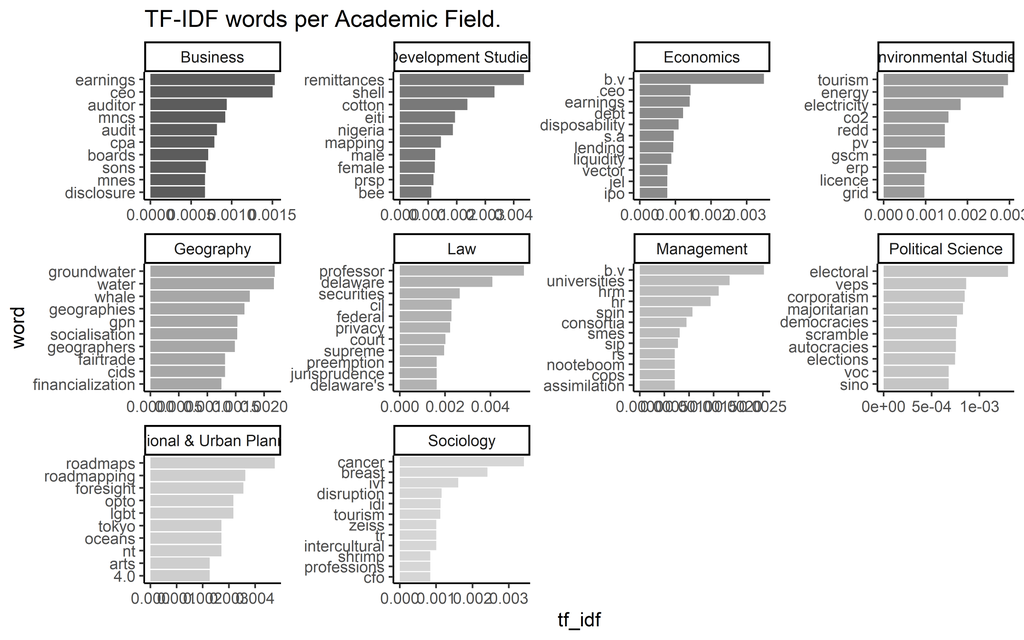

```r
# extract the words out of the abstracts.
df_words <- df_clean_final %>%
  unnest_tokens(word, abstract) %>%
  anti_join(stop_words)

custom_stopwords <- df_words %>%
  count(word, sort = T) %>%
  top_n(20) %>%
  pull(word)

# calculate tf_idf
df_words_tf_idf <- df_words %>%
  count(word, field, sort = T) %>%
  bind_tf_idf(word, field, n) %>%
  arrange(-tf_idf) %>%
  group_by(field) %>%
  top_n(10) %>%
  ungroup()

# plot tf_idf
df_words_tf_idf %>%
  mutate(word = reorder_within(word, tf_idf, field)) %>%
  ggplot(aes(word, tf_idf, fill = field)) +
  geom_col(alpha = 0.8, show.legend = FALSE) +
  scale_fill_grey() +
  facet_wrap(~ field, scales = "free") +
  scale_x_reordered() +
  coord_flip() +
  labs(title = "TF-IDF words per Academic Field.")
```

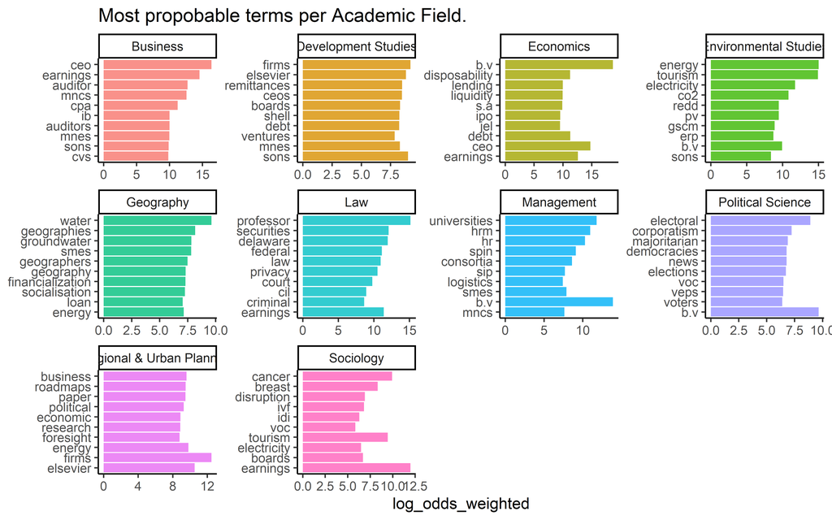

```r
# calculate log_odds
df_words_log_odds <- df_words %>%
  count(field, word) %>%
  bind_log_odds(field, word, n) %>%
  arrange(-log_odds_weighted)

# plot log_odds
df_words_log_odds %>%
  group_by(field) %>%
  slice_max(log_odds_weighted, n = 10) %>%
  mutate(word = reorder(word, log_odds_weighted)) %>%
  ungroup() %>%
  ggplot(aes(log_odds_weighted, word, fill = field)) +
  geom_col(alpha = 0.8, show.legend = F) +
  facet_wrap(~field, scales = "free") +
  scale_y_reordered() +
  labs(y = NULL,
       title = "Most propobable terms per Academic Field.")
```

```r
rm(df_words, df_words_log_odds, df_words_tf_idf)
```

Before proceeding with the topic model, I include some additional graphs to gain a deeper understanding of the structure of the dataset.

```r
# plot variance in citation count per field and per type.
df_clean_final %>%
  ggplot(aes(reorder(field, times_cited_all_databases, median), times_cited_all_databases)) +
  geom_boxplot() +
  labs(y = NULL,
       x = NULL,
       title = "Boxplot of Average Citation Count per Field",
       subtitle = "With Type as subcategory."
       )

# plot histogram of publications per type.
df_clean_final %>%
  ggplot(aes(`year_since_pub`)) +
  geom_histogram(color = "white", bins = 30) +
  scale_fill_economist() +
  labs(y = NULL,
       x = "Years since first publication.",
       title = "Histogram of publications on CPA.",
       subtitle = "From 1990 to Present")

# plot probability density of publications per type.
df_clean_final %>%
  ggplot(aes(year_since_pub, ..density..)) +
  geom_freqpoly() +
  scale_color_wsj() +
  labs(y = NULL,
       x = NULL,
       title = "Probability density of publications on CPA.")
```

[output not shown]

Now, I proceed with the structural topic model. The following steps are based on the *stm* vignette by [Roberts et al. (2014).](https://cran.r-project.org/web/packages/stm/vignettes/stmVignette.pdf).

```r
df_prep <- textProcessor(df_clean_final$abstract,
                         metadata = df_clean_final,
                         verbose = F)

out <- prepDocuments(df_prep$documents,
                     df_prep$vocab,
                     df_prep$meta,
                     verbose = F)
docs <- out$documents
vocab <- out$vocab
meta <- out$meta

short_docs <- meta %>%
  as_tibble() %>%
  select(abstract) %>%
  mutate(abstract = str_sub(abstract, 1, 50))

rm(short_docs)
```

```r
storage <- searchK(out$documents, out$vocab, K = c(0),
                   prevalence = ~ field + s(months_since_first_pub), data = meta, verbose = T)
```